# NALU initialization

# Defining NALU

$$\begin{aligned}
a_{h_\ell} &= \sum_{h_{\ell-1}=1}^{H_{\ell-1}} W_{h_{\ell}, h_{\ell-1}} z_{h_{\ell-1}} \\
m_{h_\ell} &= \exp\left(\sum_{h_{\ell-1}=1}^{H_{\ell-1}} W_{h_{\ell}, h_{\ell-1}} \log(|z_{h_{\ell-1}}| + \epsilon) \right) \\
g_{h_\ell} &= \sigma(\hat{g}_{h_\ell}),\ \hat{g}_{h_\ell} = \sum_{h_{\ell-1}=1}^{H_{\ell-1}} G_{h_{\ell}, h_{\ell-1}} z_{h_{\ell-1}} \\
z_{h_\ell} &= g_{h_\ell} a_{h_\ell} + (1 - g_{h_\ell}) m_{h_\ell} \\
\mathcal{L} &= \sum_{h_{L}=1}^{H_L} (z_{h_L} - t_{h_L})^2
\end{aligned}$$

We will not explicitly define $W_{h_{\ell}, h_{\ell-1}}$ here, as $Var[W_{h_{\ell}, h_{\ell-1}}]$ can be generalized to any construction, and we assume $E[W_{h_{\ell}, h_{\ell-1}}]$.

# Forward

## Deriving the expectation

### Output expectation

$$\begin{aligned}
E[y_{h_\ell}] &= E[g_{h_\ell} a_{h_\ell} + (1 - g_{h_\ell}) m_{h_\ell}] \\
&= E[g_{h_\ell}] E[a_{h_\ell}] + E[1 - g_{h_\ell}] E[m_{h_\ell}] \\
&= E[g_{h_\ell}] E[a_{h_\ell}] + (1 - E[g_{h_\ell}]) E[m_{h_\ell}]
\end{aligned}$$
### Gate expectation

$$\begin{aligned}
E[g_{h_\ell}] &= E[\sigma(\hat{g}_{h_\ell})] \\
&\approx \sigma(E[\hat{g}_{h_\ell}]) + \frac{1}{2}\sigma''(E[\hat{g}_{h_\ell}]) Var[\hat{g}_{h_\ell}] \\
&= \frac{1}{2} + \frac{1}{2} \cdot 0 \cdot Var[\hat{g}_{h_\ell}] \\
&= \frac{1}{2}
\end{aligned}$$

This is because we have $E[\hat{g}_{h_\ell}] = 0$:
$$\begin{aligned}
E[\hat{g}_{h_\ell}] &= E\left[\sum_{h_{\ell-1}=1}^{H_{\ell-1}} G_{h_{\ell}, h_{\ell-1}} z_{h_{\ell-1}}\right] \\
&= H_{\ell-1}E[G_{h_{\ell}, h_{\ell-1}}]E[z_{h_{\ell-1}}] \\
&= H_{\ell-1} \cdot 0 \cdot E[z_{h_{\ell-1}}] \\
&= 0
\end{aligned}$$

## Then the addition operator

$$\begin{aligned}
E[a_{h_\ell}] &= E\left[\sum_{h_{\ell-1}=1}^{H_{\ell-1}} W_{h_{\ell}, h_{\ell-1}} z_{h_{\ell-1}}\right] \\
&= H_{\ell-1}E[W_{h_{\ell}, h_{\ell-1}}]E[z_{h_{\ell-1}}] \\
&= H_{\ell-1} \cdot 0 \cdot E[z_{h_{\ell-1}}] \\
&= 0
\end{aligned}$$

### The the multiplication operator

$$\begin{aligned}
E[m_{h_\ell}] &= E\left[\exp\left(\sum_{h_{\ell-1}=1}^{H_{\ell-1}} W_{h_{\ell}, h_{\ell-1}} \log(|z_{h_{\ell-1}}| + \epsilon) \right)\right] \\
&= E\left[\prod_{h_{\ell-1}=1}^{H_{\ell-1}} \exp(W_{h_{\ell}, h_{\ell-1}} \log(|z_{h_{\ell-1}}| + \epsilon)) \right] \\
&= \prod_{h_{\ell-1}=1}^{H_{\ell-1}} E[W_{h_{\ell}, h_{\ell-1}} \log(|z_{h_{\ell-1}}| + \epsilon)] \\
&= E[W_{h_{\ell}, h_{\ell-1}} \log(|z_{h_{\ell-1}}| + \epsilon)]^{H_{\ell-1}} \\
&= E\left[(|z_{h_{\ell-1}}| + \epsilon)^{W_{h_{\ell}, h_{\ell-1}}}\right]^{H_{\ell-1}} \\
&= E\left[f(z_{h_{\ell-1}}, W_{h_{\ell}, h_{\ell-1}})\right]^{H_{\ell-1}}
\end{aligned}$$
Here we define $f$ as a non-linear transformation function of two independent stocastic variables:

$$f(z_{h_{\ell-1}}, W_{h_{\ell}, h_{\ell-1}}) = (|z_{h_{\ell-1}}| + \epsilon)^{W_{h_{\ell}, h_{\ell-1}}}$$

We then take the second order taylor approximation of $f$, around $(E[z_{h_{\ell-1}}], E[W_{h_{\ell}, h_{\ell-1}}])$.

$$\begin{aligned}
E[f(z_{h_{\ell-1}}, W_{h_{\ell}, h_{\ell-1}})] \approx
E\Bigg[&f(E[z_{h_{\ell-1}}], E[W_{h_{\ell}, h_{\ell-1}}])\\
&+ \begin{bmatrix}
z_{h_{\ell-1}} - E[z_{h_{\ell-1}}] \\ W_{h_{\ell}, h_{\ell-1}} - E[W_{h_{\ell}, h_{\ell-1}}]
\end{bmatrix}^T \begin{bmatrix}
\frac{\partial f(z_{h_{\ell-1}}, W_{h_{\ell}, h_{\ell-1}})}{\partial z_{h_{\ell-1}}} \\
\frac{\partial f(z_{h_{\ell-1}}, W_{h_{\ell}, h_{\ell-1}})}{\partial W_{h_{\ell}, h_{\ell-1}}}
\end{bmatrix} \Bigg\rvert_{
\begin{cases}
z_{h_{\ell-1}} = E[z_{h_{\ell-1}}] \\
W_{h_{\ell}, h_{\ell-1}} = E[W_{h_{\ell}, h_{\ell-1}}]
\end{cases}
} \\
&+ \frac{1}{2} \begin{bmatrix}
z_{h_{\ell-1}} - E[z_{h_{\ell-1}}] \\ W_{h_{\ell}, h_{\ell-1}} - E[W_{h_{\ell}, h_{\ell-1}}]
\end{bmatrix}^T \begin{bmatrix}
\frac{\partial^2 f(z_{h_{\ell-1}}, W_{h_{\ell}, h_{\ell-1}})}{\partial^2 z_{h_{\ell-1}}} & \frac{\partial^2 f(z_{h_{\ell-1}}, W_{h_{\ell}, h_{\ell-1}})}{\partial z_{h_{\ell-1}} \partial W_{h_{\ell}, h_{\ell-1}}} \\
\frac{\partial^2 f(z_{h_{\ell-1}}, W_{h_{\ell}, h_{\ell-1}})}{\partial z_{h_{\ell-1}} \partial W_{h_{\ell}, h_{\ell-1}}} & \frac{\partial^2 f(z_{h_{\ell-1}}, W_{h_{\ell}, h_{\ell-1}})}{\partial^2 W_{h_{\ell}, h_{\ell-1}}}
\end{bmatrix} \Bigg\rvert_{
\begin{cases}
z_{h_{\ell-1}} = E[z_{h_{\ell-1}}] \\
W_{h_{\ell}, h_{\ell-1}} = E[W_{h_{\ell}, h_{\ell-1}}]
\end{cases}
} \begin{bmatrix}
z_{h_{\ell-1}} - E[z_{h_{\ell-1}}] \\ W_{h_{\ell}, h_{\ell-1}} - E[W_{h_{\ell}, h_{\ell-1}}]
\end{bmatrix}\Bigg]
\end{aligned}$$

Because $E[z_{h_{\ell-1}} - E[z_{h_{\ell-1}}]] = 0$, $E[W_{h_{\ell}, h_{\ell-1}} - E[W_{h_{\ell}, h_{\ell-1}}]] = 0$, and $z_{h_{\ell-1}}, W_{h_{\ell}, h_{\ell-1}}$ are uncorrelated. This similifies to:

$$\begin{aligned}
E[f(z_{h_{\ell-1}}, W_{h_{\ell}, h_{\ell-1}})] \approx
&f(E[z_{h_{\ell-1}}], E[W_{h_{\ell}, h_{\ell-1}}])\\
&+ \frac{1}{2} Var\begin{bmatrix}
z_{h_{\ell-1}} \\ W_{h_{\ell}, h_{\ell-1}}
\end{bmatrix}^T \begin{bmatrix}
\frac{\partial^2 f(z_{h_{\ell-1}}, W_{h_{\ell}, h_{\ell-1}})}{\partial^2 z_{h_{\ell-1}}} \\
\frac{\partial^2 f(z_{h_{\ell-1}}, W_{h_{\ell}, h_{\ell-1}})}{\partial^2 W_{h_{\ell}, h_{\ell-1}}}
\end{bmatrix} \Bigg\rvert_{
\begin{cases}
z_{h_{\ell-1}} = E[z_{h_{\ell-1}}] \\
W_{h_{\ell}, h_{\ell-1}} = E[W_{h_{\ell}, h_{\ell-1}}]
\end{cases}
}
\end{aligned}$$

Evaluating this yields:

$$\begin{aligned}
E[f(z_{h_{\ell-1}}, W_{h_{\ell}, h_{\ell-1}})] &\approx
(|E[z_{h_{\ell-1}}]| + \epsilon)^{E[W_{h_{\ell}, h_{\ell-1}}]} \\
&+ \frac{1}{2} Var[z_{h_{\ell-1}}] (|E[z_{h_{\ell-1}}]| + \epsilon)^{E[W_{h_{\ell}, h_{\ell-1}}] - 2} E[W_{h_{\ell}, h_{\ell-1}}] (E[W_{h_{\ell}, h_{\ell-1}}] - 1) \\
&+ \frac{1}{2} Var[W_{h_{\ell}, h_{\ell-1}}] (|E[z_{h_{\ell-1}}]| + \epsilon)^{E[W_{h_{\ell}, h_{\ell-1}}]} \log(|E[z_{h_{\ell-1}}]| + \epsilon)^2 \\
&=1 + \frac{1}{2} Var[W_{h_{\ell}, h_{\ell-1}}] \log(|E[z_{h_{\ell-1}}]| + \epsilon)^2
\end{aligned}$$

This gives the expectation:

$$\begin{aligned}
E[m_{h_\ell}] &= E\left[f(z_{h_{\ell-1}}, W_{h_{\ell}, h_{\ell-1}})\right]^{H_{\ell-1}} \\
&\approx\left(1 + \frac{1}{2} Var[W_{h_{\ell}, h_{\ell-1}}] \log(|E[z_{h_{\ell-1}}]| + \epsilon)^2\right)^{H_{\ell-1}}
\end{aligned}$$

As this expectation is of particuar interrest, we evaluate the error of the approximation, where $W_{h_{\ell}, h_{\ell-1}} \sim U[-r_w,r_w]$ and $z_{h_{\ell-1}} \sim U[0, r_z]$. These distributions are what is used in the simple function task is done.

```r
m.expectation.taylor = function (r.w, r.z) {
  w.var = (1/3) * r.w^2;
  z.e = (1/2) * r.z;
  return(1 + 0.5*w.var*log(abs(z.e) + 10^-8)^2);
}
m.expectation.simulation = function (r.w, r.z) {
  w.samples = runif(100000, -r.w, r.w);
  z.samples = runif(100000, 0, r.z);
  f.samples = exp(w.samples * log(z.samples + 10^-8));
  return(mean(f.samples));
}

m.expectation.input = expand.grid(r.w = seq(0.001, 0.5, 0.011), r.z = seq(1, 50, 1))
m.expectation.error = mapply(function(r.w,r.z) {
  return(m.expectation.taylor(r.w, r.z) - m.expectation.simulation(r.w, r.z))
}, m.expectation.input$r.w, m.expectation.input$r.z)
```

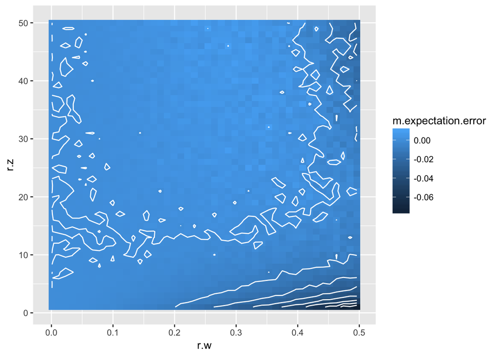

```r
p = ggplot(cbind(m.expectation.input, m.expectation.error), aes(r.w, r.z)) +
  geom_raster(aes(fill = m.expectation.error)) +
  geom_contour(aes(z = m.expectation.error), colour='white')
print(p)
```

### Total expectation

We thus have that the expectation of $E[y_{h_\ell}]$ is:

$$\begin{aligned}
E[z_{h_\ell}] &= E[g_{h_\ell}] E[a_{h_\ell}] + (1 - E[g_{h_\ell}]) E[m_{h_\ell}] \\
&\approx \frac{1}{2} \cdot 0 + \frac{1}{2} \left(1 + \frac{1}{2} Var[W_{h_{\ell}, h_{\ell-1}}] \log(|E[z_{h_{\ell-1}}]| + \epsilon)^2\right)^{H_{\ell-1}}
\end{aligned}$$

This is somewhat problematic, as even in the best case ($|E[z_{h_{\ell-1}}]| + \epsilon = 1$) we have $E[y_{h_\ell}] = \frac{1}{2}$.

This problem could be solved, by using a bias parameter. Such that one have:

$$z_{h_\ell} = g_{h_\ell} a_{h_\ell} + (1 - g_{h_\ell}) (m_{h_\ell} + b_{h_\ell}),\ E[b_{h_\ell}] = -1$$

However, it still seams problematic as $\frac{1}{2} Var[W_{h_{\ell}, h_{\ell-1}}] \log(|E[z_{h_{\ell-1}}]| + \epsilon) \approx 0$ only holds for a very small variance of $W_{h_{\ell}}$ and a very limited range of $E[z_{h_{\ell-1}}]$.

## Diriving the variance

### Output variance

Assuming for simplicity that $Cov[a_{h_\ell}, g_{h_\ell}] = 0$, $Cov[m_{h_\ell}, g_{h_\ell}] = 0$, $Cov[a_{h_\ell}, m_{h_\ell}] = 0$. Which is definetly not true, because they all depend on $z_{h_{\ell-1}}$ and addition and multiplication are correlated.

$$\begin{aligned}
Var[z_{h_\ell}] &\approx E[g_{h_\ell}]^2 Var[a_{h_\ell}] + E[1 - g_{h_\ell}]^2 Var[m_{h_\ell}] \\
&+ E[a_{h_\ell}]^2 Var[g_{h_\ell}] + E[m_{h_\ell}]^2 Var[1 - g_{h_\ell}] \\
&+ Var[g_{h_\ell}] Var[a_{h_\ell}] + Var[1 - g_{h_\ell}] Var[m_{h_\ell}] \\
&= E[g_{h_\ell}]^2 Var[a_{h_\ell}] + \left(1 - E[g_{h_\ell}]\right)^2 Var[m_{h_\ell}] \\
&+ E[a_{h_\ell}]^2 Var[g_{h_\ell}] + E[m_{h_\ell}]^2 Var[g_{h_\ell}] \\
&+ Var[g_{h_\ell}] Var[a_{h_\ell}] + Var[g_{h_\ell}] Var[m_{h_\ell}]
\end{aligned}$$

### Gate Variance

Recall that $Var[\hat{g}_{h_\ell}] = H_{\ell-1} Var[G_{h_{\ell-1}, h_\ell}] E[z_{h_\ell}^2]$ and that $E[\hat{g}_{h_\ell}] = 0$.

$$\begin{aligned}
Var[g_{h_\ell}] &= Var[\sigma(\hat{g}_{h_\ell})] \\
&= \sigma'(E[\hat{g}_{h_\ell}])^2 Var[\hat{g}_{h_\ell}] + \frac{1}{2} \sigma''(E[\hat{g}_{h_\ell}])^2 Var[\hat{g}_{h_\ell}]^2 \\
&= \left(\frac{1}{4}\right)^2 Var[\hat{g}_{h_\ell}] + \frac{1}{2} \cdot 0 \cdot Var[\hat{g}_{h_\ell}]^2 \\
&= \frac{1}{16} Var[\hat{g}_{h_\ell}] \\
&=\frac{1}{16} H_{\ell-1} Var\left[G_{h_{\ell}, h_{\ell-1}}\right] Var[z_{h_{\ell-1}}]
\end{aligned}$$

### Addition operation

$$\begin{aligned}
Var[a_{h_\ell}] &= Var\left[\sum_{h_{\ell-1}=1}^{H_{\ell-1}} W_{h_{\ell}, h_{\ell-1}} z_{h_{\ell-1}}\right] \\
&= H_{\ell-1} Var\left[W_{h_{\ell}, h_{\ell-1}}\right] Var[z_{h_{\ell-1}}]
\end{aligned}$$

The same result, was used for the $Var[\hat{g}_{h_\ell}]$.

#### Multiplication operation

$$\begin{aligned}
Var[m_{h_\ell}] &= Var\left[\exp\left(\sum_{h_{\ell-1}=1}^{H_{\ell-1}} W_{h_{\ell}, h_{\ell-1}} \log(|z_{h_{\ell-1}}| + \epsilon) \right)\right] \\
&= Var\left[\prod_{h_{\ell-1}=1}^{H_{\ell-1}} (|z_{h_{\ell-1}}| + \epsilon)^{W_{h_{\ell}, h_{\ell-1}}} \right] \\
&= E\left[\left(\prod_{h_{\ell-1}=1}^{H_{\ell-1}} (|z_{h_{\ell-1}}| + \epsilon)^{W_{h_{\ell}, h_{\ell-1}}}\right)^2 \right]
- E\left[\prod_{h_{\ell-1}=1}^{H_{\ell-1}} (|z_{h_{\ell-1}}| + \epsilon)^{W_{h_{\ell}, h_{\ell-1}}}\right]^2 \\
&= E\left[\prod_{h_{\ell-1}=1}^{H_{\ell-1}} (|z_{h_{\ell-1}}| + \epsilon)^{2 \cdot W_{h_{\ell}, h_{\ell-1}}} \right]
- E\left[\prod_{h_{\ell-1}=1}^{H_{\ell-1}} (|z_{h_{\ell-1}}| + \epsilon)^{W_{h_{\ell}, h_{\ell-1}}}\right]^2 \\
&= E\left[f(z_{h_{\ell-1}}, 2 \cdot W_{h_{\ell}, h_{\ell-1}}) \right]^{H_{\ell-1}}
- E\left[f(z_{h_{\ell-1}}, W_{h_{\ell}, h_{\ell-1}})\right]^{2\cdot H_{\ell-1}}
\end{aligned}$$

We already have from previus results that:

$$E\left[f(z_{h_{\ell-1}}, W_{h_{\ell}, h_{\ell-1}})\right] \approx 1 + \frac{1}{2} Var[W_{h_{\ell}, h_{\ell-1}}] \log(|E[z_{h_{\ell-1}}]| + \epsilon)^2$$

By substitution of variable we have that:

$$\begin{aligned}
E\left[f(z_{h_{\ell-1}}, 2 \cdot W_{h_{\ell}, h_{\ell-1}})\right] &\approx 1 + \frac{1}{2} Var[2 \cdot W_{h_{\ell}, h_{\ell-1}}] \log(|E[z_{h_{\ell-1}}]| + \epsilon)^2 \\
&= \approx 1 + 2 \cdot Var[W_{h_{\ell}, h_{\ell-1}}] \log(|E[z_{h_{\ell-1}}]| + \epsilon)^2
\end{aligned}$$
This gives the variance:

$$\begin{aligned}
Var[m_{h_\ell}] &= Var\left[\exp\left(\sum_{h_{\ell-1}=1}^{H_{\ell-1}} W_{h_{\ell}, h_{\ell-1}} \log(|z_{h_{\ell-1}}| + \epsilon) \right)\right] \\
&= E\left[f(z_{h_{\ell-1}}, 2 \cdot W_{h_{\ell}, h_{\ell-1}}) \right]^{H_{\ell-1}}
- E\left[f(z_{h_{\ell-1}}, W_{h_{\ell}, h_{\ell-1}})\right]^{2\cdot H_{\ell-1}} \\
&\approx \left(1 + 2 \cdot Var[W_{h_{\ell}, h_{\ell-1}}] \log(|E[z_{h_{\ell-1}}]| + \epsilon)^2\right)^{H_{\ell-1}} \\
&- \left(1 + \frac{1}{2} \cdot Var[W_{h_{\ell}, h_{\ell-1}}] \log(|E[z_{h_{\ell-1}}]| + \epsilon)^2\right)^{2\cdot H_{\ell-1}}
\end{aligned}$$

```r
m.variance.taylor = function (r.w, r.z) {
  w.var = (1/3) * r.w^2;
  z.e = (1/2) * r.z;
  return((1 + 2*w.var*log(abs(z.e) + 10^-8)^2) - (1 + 0.5*w.var*log(abs(z.e) + 10^-8)^2)^2);
}
m.variance.simulation = function (r.w, r.z) {
  w.samples = runif(100000, -r.w, r.w);
  z.samples = runif(100000, 0, r.z);
  f.samples = exp(w.samples * log(z.samples + 10^-8));
  return(var(f.samples));
}

m.variance.input = expand.grid(r.w = seq(0.001, 0.5, 0.011), r.z = seq(1, 50, 1))
m.variance.error = mapply(function(r.w,r.z) {
  return(m.variance.taylor(r.w, r.z) - m.variance.simulation(r.w, r.z))
}, m.variance.input$r.w, m.variance.input$r.z)
```

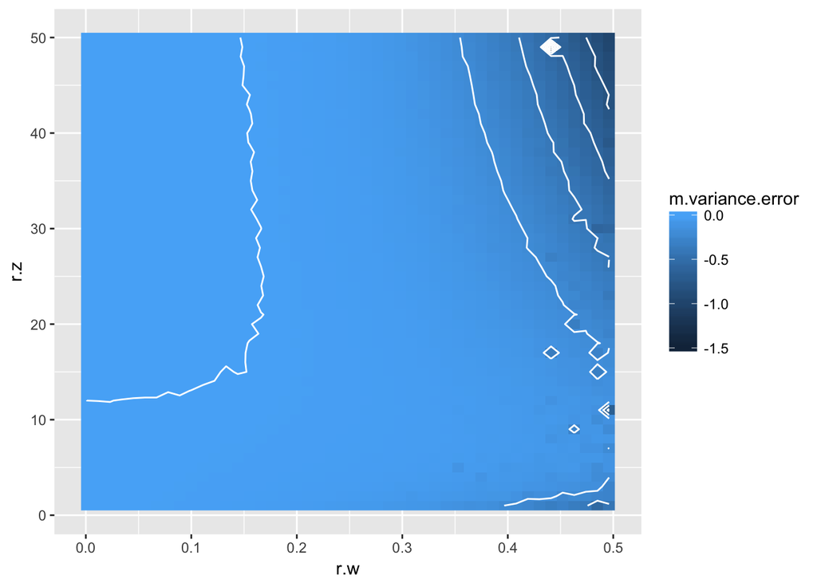

```r
p = ggplot(cbind(m.variance.input, m.variance.error), aes(r.w, r.z)) +
  geom_raster(aes(fill = m.variance.error)) +
  geom_contour(aes(z = m.variance.error), colour='white')
print(p)
```

### Total variance

Combining these results we have:

$$\begin{aligned}
Var[z_{h_\ell}] &\approx E[g_{h_\ell}]^2 Var[a_{h_\ell}] + \left(1 - E[g_{h_\ell}]\right)^2 Var[m_{h_\ell}] \\
&+ E[a_{h_\ell}]^2 Var[g_{h_\ell}] + E[m_{h_\ell}]^2 Var[g_{h_\ell}] \\
&+ Var[g_{h_\ell}] Var[a_{h_\ell}] + Var[g_{h_\ell}] Var[m_{h_\ell}] \\
&= \left(\frac{1}{2}\right)^2 Var[a_{h_\ell}] + \left(\frac{1}{2}\right)^2 Var[m_{h_\ell}] \\
&+ 0 \cdot Var[g_{h_\ell}] + E[m_{h_\ell}]^2 Var[g_{h_\ell}] \\
&+ Var[g_{h_\ell}] Var[a_{h_\ell}] + Var[g_{h_\ell}] Var[m_{h_\ell}] \\
&= \frac{1}{4} \left(Var[a_{h_\ell}] + Var[m_{h_\ell}]\right) \\
&+ Var[g_{h_\ell}] \left(Var[a_{h_\ell}] + E[m_{h_\ell}]^2 + Var[m_{h_\ell}]\right) \\
&= \frac{1}{4} \left(Var[a_{h_\ell}] + Var[m_{h_\ell}]\right) \\
&+ Var[g_{h_\ell}] \left(Var[a_{h_\ell}] + E[m_{h_\ell}^2]\right)
\end{aligned}$$

As the expressing for $Var[m_{h_\ell}]$ is rather larger and hard to intrepert, we can instead collect $Var[a_{h_\ell}]$, $E[m_{h_\ell}^2]$, and $E[m_{h_\ell}]^2$.

$$\begin{aligned}
Var[z_{h_\ell}] &\approx \frac{1}{4} \left(Var[a_{h_\ell}] + Var[m_{h_\ell}]\right) \\
&+ Var[g_{h_\ell}] \left(Var[a_{h_\ell}] + E[m_{h_\ell}^2]\right) \\
&= \frac{1}{4}Var[a_{h_\ell}] + \frac{1}{4}E[m_{h_\ell}^2] - \frac{1}{4} E[m_{h_\ell}]^2 \\
&+ Var[g_{h_\ell}] Var[a_{h_\ell}] + Var[g_{h_\ell}]E[m_{h_\ell}^2] \\
&= Var[a_{h_\ell}] \left(\frac{1}{4} + Var[g_{h_\ell}]\right) \\
&+ E[m_{h_\ell}^2] \left(\frac{1}{4} + Var[g_{h_\ell}]\right) - \frac{1}{4} E[m_{h_\ell}]^2 \\
&= \left(Var[a_{h_\ell}] + E[m_{h_\ell}^2]\right) \left(\frac{1}{4} + Var[g_{h_\ell}]\right) - \frac{1}{4} E[m_{h_\ell}]^2
\end{aligned}$$

Inserting $Var[g_{h_\ell}], Var[a_{h_\ell}], E[m_{h_\ell}^2]]$ this yeids:

$$\begin{aligned}
Var[z_{h_\ell}] &\approx \left(Var[a_{h_\ell}] + E[m_{h_\ell}^2]\right) \left(\frac{1}{4} + Var[g_{h_\ell}]\right) - \frac{1}{4} E[m_{h_\ell}]^2 \\
&= \left(H_{\ell-1} Var[W_{h_{\ell-1},h_\ell}] Var[z_{h_{\ell-1}}] + \left(1 + 2 \cdot Var[W_{h_{\ell}, h_{\ell-1}}] \log(|E[z_{h_{\ell-1}}]| + \epsilon)^2\right)^{H_{\ell-1}}\right)\left(\frac{1}{4} + \frac{1}{16} H_{\ell-1} Var[G_{h_{\ell-1}, h_\ell}] Var[z_{h_{\ell-1}}]\right) \\
&- \frac{1}{4}\left(1 + \frac{1}{2} \cdot Var[W_{h_{\ell}, h_{\ell-1}}] \log(|E[z_{h_{\ell-1}}]| + \epsilon)^2\right)^{2\cdot H_{\ell-1}}
\end{aligned}$$

Even for the best case, where $|E[z_{h_{\ell-1}}]| = 1$ (NOTE: this is not a desired property in terms of exploding/vanishing gradient), this shows that it is not possible to maintain variance though the layers:

$$\begin{aligned}
Var[z_{h_\ell}] &= \left(H_{\ell-1} Var[W_{h_{\ell-1},h_\ell}] Var[z_{h_{\ell-1}}] + 1\right)\left(\frac{1}{4} + \frac{1}{16} H_{\ell-1} Var[G_{h_{\ell-1}, h_\ell}]Var[z_{h_{\ell-1}}]\right) - \frac{1}{4} \\
&=\frac{1}{4} H_{\ell-1} Var[W_{h_{\ell-1},h_\ell}] Var[z_{h_{\ell-1}}] + H_{\ell-1}^2 Var[W_{h_{\ell-1},h_\ell}] Var[G_{h_{\ell-1}, h_\ell}] Var[z_{h_{\ell-1}}]^2 + \frac{1}{16} H_{\ell-1} Var[G_{h_{\ell-1}, h_\ell}]Var[z_{h_{\ell-1}}] \\
&= H_{\ell-1} Var[z_{h_{\ell-1}}] \left( \frac{1}{4} Var[W_{h_{\ell-1},h_\ell}] + H_{\ell-1} Var[W_{h_{\ell-1},h_\ell}] Var[G_{h_{\ell-1}, h_\ell}] Var[z_{h_{\ell-1}}] + \frac{1}{16} Var[G_{h_{\ell-1}, h_\ell}]\right)
\end{aligned}$$
As it can be seen, maintaining variance though the layers ($Var[z_{h_\ell}] = Var[z_{h_{\ell-1}}]$) is not possible due to the $Var[z_{h_{\ell-1}}]^2$ term.

In the very best case where $Var[z_{h_{\ell-1}}] = 1$, then:

$$\begin{aligned}
1 &= H_{\ell-1} \left( \frac{1}{4} Var[W_{h_{\ell-1},h_\ell}] + H_{\ell-1} Var[W_{h_{\ell-1},h_\ell}] Var[G_{h_{\ell-1}, h_\ell}] + \frac{1}{16} Var[G_{h_{\ell-1}, h_\ell}]\right)
\end{aligned}$$

Using the same variance for both $W_{h_{\ell-1},h_\ell}$ and $G_{h_{\ell-1}, h_\ell}$ we have:

$$\begin{aligned}
1 &= H_{\ell-1} \left( \frac{1}{4} Var[W_{h_{\ell-1},h_\ell}] + H_{\ell-1} Var[W_{h_{\ell-1},h_\ell}]^2 + \frac{1}{16} Var[W_{h_{\ell-1}, h_\ell}]\right)
\end{aligned}$$

Solving this yeilds:

$$Var[W_{h_{\ell-1},h_\ell}] = Var[G_{h_{\ell-1}, h_\ell}] = \frac{-\frac{5}{32} + \sqrt{\frac{1049}{1024}}}{H_{\ell-1}} \approx \frac{0.8558834210}{H_{\ell-1}}$$

Assuming from Glorot, that we would get a similar result for the backward pass. We have:

$$Var[W_{h_{\ell-1},h_\ell}] = Var[G_{h_{\ell-1}, h_\ell}] \approx \frac{1.711766842}{H_{\ell-1} + H_{\ell}}$$

## Backpropergation

We wish to ensure $E[\delta_{h_\ell}] = 0$ and $Var[\delta_{h_\ell}] = Var[\delta_{h_{\ell+1}}]$.

We have:

## Expectation

$$E[\delta_{h_\ell}] = E\left[\sum_{h_{\ell+1}=1}^{H_{\ell+1}} \delta_{h_{\ell+1}} \frac{\partial z_{h_{\ell+1}}}{\partial z_{h_\ell}}\right] = H_{\ell+1} E[\delta_{h_{\ell+1}}] E\left[\frac{\partial z_{h_{\ell+1}}}{\partial z_{h_\ell}}\right]$$

### NALU operation

$$\begin{aligned}
E\left[\frac{\partial z_{h_{\ell+1}}}{\partial z_{h_\ell}}\right] &= E[g_{h_{\ell+1}}]E\left[\frac{\partial a_{h_{\ell+1}}}{\partial z_{h_\ell}}\right] + E\left[1 - g_{h_{\ell+1}}\right] E\left[\frac{\partial m_{h_{\ell+1}}}{\partial z_{h_\ell}}\right] + E\left[a_{h_{\ell+1}} - m_{h_{\ell+1}}\right] E\left[\frac{\partial g_{h_{\ell+1}}}{\partial z_{h_\ell}}\right] \\
&= E[g_{h_{\ell+1}}]E\left[\frac{\partial a_{h_{\ell+1}}}{\partial z_{h_\ell}}\right] + (E[1] - E[g_{h_{\ell+1}}]) E\left[\frac{\partial m_{h_{\ell+1}}}{\partial z_{h_\ell}}\right] + (E[a_{h_{\ell+1}}] - E[m_{h_{\ell+1}}]) E\left[\frac{\partial g_{h_{\ell+1}}}{\partial z_{h_\ell}}\right] \\
&= \frac{1}{2}E\left[\frac{\partial a_{h_{\ell+1}}}{\partial z_{h_\ell}}\right] + \frac{1}{2} E\left[\frac{\partial m_{h_{\ell+1}}}{\partial z_{h_\ell}}\right] - E[m_{h_{\ell+1}}] E\left[\frac{\partial g_{h_{\ell+1}}}{\partial z_{h_\ell}}\right]
\end{aligned}$$

### Addition operator

$$E\left[\frac{\partial a_{h_{\ell+1}}}{\partial z_{h_\ell}}\right] = E[W_{h_{\ell+1},h_\ell}] = 0$$

### Gate

$$E\left[\frac{\partial g_{h_{\ell+1}}}{\partial z_{h_\ell}}\right] = E[\sigma(\hat{g}_{h_{\ell+1}}) (1 - \sigma(\hat{g}_{h_{\ell+1}}))] E[G_{h_{\ell+1},h_{\ell}}] = E[\sigma(\hat{g}_{h_{\ell+1}}) (1 - \sigma(\hat{g}_{h_{\ell+1}}))] \cdot 0 = 0$$

### Total expectation

$$\begin{aligned}
E\left[\frac{\partial z_{h_{\ell+1}}}{\partial z_{h_\ell}}\right] &= \frac{1}{2}E\left[\frac{\partial a_{h_{\ell+1}}}{\partial z_{h_\ell}}\right] + \frac{1}{2} E\left[\frac{\partial m_{h_{\ell+1}}}{\partial z_{h_\ell}}\right] - E[m_{h_{\ell+1}}] E\left[\frac{\partial g_{h_{\ell+1}}}{\partial z_{h_\ell}}\right] \\
&= \frac{1}{2}\cdot 0 + \frac{1}{2} \cdot 0 - E[m_{h_{\ell+1}}] \cdot 0 \\
&= 0
\end{aligned}$$

Thus the expectation is as we wish.

## Variance

$$Var[\delta_{h_\ell}] = Var\left[\sum_{h_{\ell+1}=1}^{H_{\ell+1}} \delta_{h_{\ell+1}} \frac{\partial z_{h_{\ell+1}}}{\partial z_{h_\ell}}\right] = H_{\ell+1} Var\left[\delta_{h_{\ell+1}} \cdot \frac{\partial z_{h_{\ell+1}}}{\partial z_{h_\ell}}\right]$$

Assuming $Cov[\delta_{h_{\ell+1}}, \frac{\partial z_{h_{\ell+1}}}{\partial z_{h_\ell}}] = 0$. We have:

$$Var[\delta_{h_\ell}] = H_{\ell+1} \left(E[\delta_{h_{\ell+1}}]^2 Var\left[\frac{\partial z_{h_{\ell+1}}}{\partial z_{h_\ell}}\right] + E\left[\frac{\partial z_{h_{\ell+1}}}{\partial z_{h_\ell}}\right]^2 Var[\delta_{h_{\ell+1}}] + Var[\delta_{h_{\ell+1}}] Var\left[\frac{\partial z_{h_{\ell+1}}}{\partial z_{h_\ell}}\right] \right)$$

As $E\left[\frac{\partial z_{h_{\ell+1}}}{\partial z_{h_\ell}}\right] = 0$ have already been proven, and it is resonable to assume that $E[\delta_{h_{\ell+1}}] = 0$. This simplifies to:

$$Var[\delta_{h_\ell}] = H_{\ell+1} Var[\delta_{h_{\ell+1}}] Var\left[\frac{\partial z_{h_{\ell+1}}}{\partial z_{h_\ell}}\right]$$

This means that that the desired property is:

$$Var\left[\frac{\partial z_{h_{\ell+1}}}{\partial z_{h_\ell}}\right] = \frac{1}{H_{\ell+1}}$$

### NALU operator

$$\begin{aligned}
Var\left[\frac{\partial z_{h_{\ell+1}}}{\partial z_{h_\ell}}\right] &= Var\left[g_{h_{\ell+1}} \frac{\partial a_{h_{\ell+1}}}{\partial z_{h_\ell}} + (1 - g_{h_{\ell+1}}) \frac{\partial m_{h_{\ell+1}}}{\partial z_{h_\ell}} + (a_{h_{\ell+1}} - m_{h_{\ell+1}}) \frac{\partial g_{h_{\ell+1}}}{\partial z_{h_\ell}}\right] \\
\end{aligned}$$

Assuming only dependence between $g_{h_{\ell+1}} \frac{\partial a_{h_{\ell+1}}}{\partial z_{h_\ell}}$ and $(1 - g_{h_{\ell+1}}) \frac{\partial m_{h_{\ell+1}}}{\partial z_{h_\ell}}$ this gives:

$$\begin{aligned}
Var\left[\frac{\partial z_{h_{\ell+1}}}{\partial z_{h_\ell}}\right] &\approx Var\left[(a_{h_{\ell+1}} - m_{h_{\ell+1}}) \frac{\partial g_{h_{\ell+1}}}{\partial z_{h_\ell}}\right] \\
&+ Var\left[g_{h_{\ell+1}} \frac{\partial a_{h_{\ell+1}}}{\partial z_{h_\ell}}\right] + Var\left[(1 - g_{h_{\ell+1}}) \frac{\partial m_{h_{\ell+1}}}{\partial z_{h_\ell}}\right] + 2 Cov\left[g_{h_{\ell+1}} \frac{\partial a_{h_{\ell+1}}}{\partial z_{h_\ell}}, (1 - g_{h_{\ell+1}}) \frac{\partial m_{h_{\ell+1}}}{\partial z_{h_\ell}}\right]
\end{aligned}$$

Assuming only dependence between $g_{h_{\ell+1}}$ and $(1 - g_{h_{\ell+1}})$ one have:

$$\begin{aligned}
Cov\left[g_{h_{\ell+1}} \frac{\partial a_{h_{\ell+1}}}{\partial z_{h_\ell}}, (1 - g_{h_{\ell+1}}) \frac{\partial m_{h_{\ell+1}}}{\partial z_{h_\ell}}\right] &\approx E\left[\frac{\partial a_{h_{\ell+1}}}{\partial z_{h_\ell}}\right] E\left[\frac{\partial m_{h_{\ell+1}}}{\partial z_{h_\ell}}\right] Cov\left[g_{h_{\ell+1}}, (1 - g_{h_{\ell+1}})\right] \\
&= 0 \cdot 0 \cdot Cov\left[g_{h_{\ell+1}}, (1 - g_{h_{\ell+1}})\right] \\
&= 0
\end{aligned}$$

Thus one have:

$$\begin{aligned}
Var\left[\frac{\partial z_{h_{\ell+1}}}{\partial z_{h_\ell}}\right] &\approx Var\left[(a_{h_{\ell+1}} - m_{h_{\ell+1}}) \frac{\partial g_{h_{\ell+1}}}{\partial z_{h_\ell}}\right] + Var\left[g_{h_{\ell+1}} \frac{\partial a_{h_{\ell+1}}}{\partial z_{h_\ell}}\right] + Var\left[(1 - g_{h_{\ell+1}}) \frac{\partial m_{h_{\ell+1}}}{\partial z_{h_\ell}}\right]
\end{aligned}$$

Assuming again independence between each term, this can be expressed as:

$$\begin{aligned}
Var\left[\frac{\partial z_{h_{\ell+1}}}{\partial z_{h_\ell}}\right] &\approx E[a_{h_{\ell+1}} - m_{h_{\ell+1}}]^2 Var\left[ \frac{\partial g_{h_{\ell+1}}}{\partial z_{h_\ell}}\right] &&+ Var[a_{h_{\ell+1}} - m_{h_{\ell+1}}] E\left[ \frac{\partial g_{h_{\ell+1}}}{\partial z_{h_\ell}}\right]^2 &&+ Var[a_{h_{\ell+1}} - m_{h_{\ell+1}}] Var\left[ \frac{\partial g_{h_{\ell+1}}}{\partial z_{h_\ell}}\right] \\
&+ E[g_{h_{\ell+1}}]^2 Var\left[\frac{\partial a_{h_{\ell+1}}}{\partial z_{h_\ell}}\right] &&+ Var[g_{h_{\ell+1}}] E\left[\frac{\partial a_{h_{\ell+1}}}{\partial z_{h_\ell}}\right]^2 &&+ Var\left[\frac{\partial a_{h_{\ell+1}}}{\partial z_{h_\ell}}\right] Var[g_{h_{\ell+1}}] \\
&+ E[1 - g_{h_{\ell+1}}]^2 Var\left[\frac{\partial m_{h_{\ell+1}}}{\partial z_{h_\ell}}\right] &&+ Var[1 - g_{h_{\ell+1}}] E\left[\frac{\partial m_{h_{\ell+1}}}{\partial z_{h_\ell}}\right]^2 &&+ Var[1 - g_{h_{\ell+1}}] Var\left[\frac{\partial m_{h_{\ell+1}}}{\partial z_{h_\ell}}\right]
\end{aligned}$$

Inserting the definities for the expectations that have already been derived to a simple value, one gets:

$$\begin{aligned}
Var\left[\frac{\partial z_{h_{\ell+1}}}{\partial z_{h_\ell}}\right] &\approx E[m_{h_{\ell+1}}]^2 Var\left[ \frac{\partial g_{h_{\ell+1}}}{\partial z_{h_\ell}}\right] &&+ Var[a_{h_{\ell+1}} - m_{h_{\ell+1}}] \cdot 0 &&+ Var[a_{h_{\ell+1}} - m_{h_{\ell+1}}] Var\left[ \frac{\partial g_{h_{\ell+1}}}{\partial z_{h_\ell}}\right] \\
&+ \frac{1}{4} Var\left[\frac{\partial a_{h_{\ell+1}}}{\partial z_{h_\ell}}\right] &&+ Var[g_{h_{\ell+1}}] \cdot 0 &&+ Var\left[\frac{\partial a_{h_{\ell+1}}}{\partial z_{h_\ell}}\right] Var[g_{h_{\ell+1}}] \\
&+ \frac{1}{4} Var\left[\frac{\partial m_{h_{\ell+1}}}{\partial z_{h_\ell}}\right] &&+ Var[g_{h_{\ell+1}}] \cdot 0 &&+ Var[ g_{h_{\ell+1}}] Var\left[\frac{\partial m_{h_{\ell+1}}}{\partial z_{h_\ell}}\right]
\end{aligned}$$

Collecting the variances of the derivaties:

$$\begin{aligned}
Var\left[\frac{\partial z_{h_{\ell+1}}}{\partial z_{h_\ell}}\right] &\approx \left(E[m_{h_{\ell+1}}]^2 + Var[a_{h_{\ell+1}} - m_{h_{\ell+1}}]\right) Var\left[\frac{\partial g_{h_{\ell+1}}}{\partial z_{h_\ell}}\right] \\
&+ \left(\frac{1}{4} + Var[g_{h_{\ell+1}}]\right) Var\left[\frac{\partial a_{h_{\ell+1}}}{\partial z_{h_\ell}}\right] \\
&+ \left(\frac{1}{4} + Var[g_{h_{\ell+1}}]\right) Var\left[\frac{\partial m_{h_{\ell+1}}}{\partial z_{h_\ell}}\right]
\end{aligned}$$

Assuming again $Cov[a_{h_{\ell+1}}, m_{h_{\ell+1}}] = 0$:

$$\begin{aligned}
E[m_{h_{\ell+1}}]^2 + Var[a_{h_{\ell+1}} - m_{h_{\ell+1}}] &\approx E[m_{h_{\ell+1}}]^2 + Var[a_{h_{\ell+1}}] + Var[ m_{h_{\ell+1}}] \\
&= E[m_{h_{\ell+1}}]^2 + Var[a_{h_{\ell+1}}] + E[m_{h_{\ell+1}}^2] - E[m_{h_{\ell+1}}]^2 \\
&= Var[a_{h_{\ell+1}}] + E[m_{h_{\ell+1}}^2]
\end{aligned}$$

$$\begin{aligned}
Var\left[\frac{\partial z_{h_{\ell+1}}}{\partial z_{h_\ell}}\right] &\approx \left(E[m_{h_{\ell+1}}^2] + Var[a_{h_{\ell+1}}]\right) Var\left[\frac{\partial g_{h_{\ell+1}}}{\partial z_{h_\ell}}\right] \\
&+ \left(\frac{1}{4} + Var[g_{h_{\ell+1}}]\right) Var\left[\frac{\partial a_{h_{\ell+1}}}{\partial z_{h_\ell}}\right] \\
&+ \left(\frac{1}{4} + Var[g_{h_{\ell+1}}]\right) Var\left[\frac{\partial m_{h_{\ell+1}}}{\partial z_{h_\ell}}\right]
\end{aligned}$$

### Addtion operator

$$Var\left[\frac{\partial a_{h_{\ell+1}}}{\partial z_{h_\ell}}\right] = Var[W_{h_{\ell+1}, h_{\ell}}]$$

### Multiplication operator

$$\begin{aligned}
Var\left[\frac{\partial m_{h_{\ell+1}}}{\partial z_{h_\ell}}\right] &= Var\left[m_{h_{\ell+1}} W_{h_{\ell+1}, h_{\ell}} \frac{\mathrm{abs}'(z_{h_{\ell}})}{|z_{h_{\ell}}| + \epsilon}\right]
\end{aligned}$$

Assuming independence between all terms:

$$\begin{aligned}
Var\left[\frac{\partial m_{h_{\ell+1}}}{\partial z_{h_\ell}}\right] &= E[m_{h_{\ell+1}}^2] E[W_{h_{\ell+1}, h_{\ell}}^2] E\left[\left( \frac{\mathrm{abs}'(z_{h_{\ell}})}{|z_{h_{\ell}}| + \epsilon}\right)^2\right] - E[m_{h_{\ell+1}}]^2 E[W_{h_{\ell+1}, h_{\ell}}]^2 E\left[ \frac{\mathrm{abs}'(z_{h_{\ell}})}{|z_{h_{\ell}}| + \epsilon}\right]^2 \\
&= E[m_{h_{\ell+1}}^2] Var[W_{h_{\ell+1}, h_{\ell}}] E\left[\left( \frac{\mathrm{abs}'(z_{h_{\ell}})}{|z_{h_{\ell}}| + \epsilon}\right)^2\right] - E[m_{h_{\ell+1}}]^2 \cdot 0 \cdot E\left[ \frac{\mathrm{abs}'(z_{h_{\ell}})}{|z_{h_{\ell}}| + \epsilon}\right]^2
\end{aligned}$$

Using taylor approximation:

$$E\left[\left( \frac{\mathrm{abs}'(z_{h_{\ell}})}{|z| + \epsilon}\right)^2\right] \approx\frac{1}{\left(|E[z_{h_{\ell}}]| + \epsilon\right)^2} + \frac{1}{2} \frac{6}{\left(|E[z_{h_{\ell}}]| + \epsilon\right)^4} Var[z_{h_{\ell}}] = \frac{1}{\left(|E[z_{h_{\ell}}]| + \epsilon\right)^2} + \frac{3}{\left(|E[z_{h_{\ell}}]| + \epsilon\right)^4} Var[z_{h_{\ell}}]$$

Thus the variance is:

$$Var\left[\frac{\partial m_{h_{\ell+1}}}{\partial z_{h_\ell}}\right] = E[m_{h_{\ell+1}}^2] Var[W_{h_{\ell+1}, h_{\ell}}] \left(\frac{1}{\left(|E[z_{h_{\ell}}]| + \epsilon\right)^2} + \frac{3}{\left(|E[z_{h_{\ell}}]| + \epsilon\right)^4} Var[z_{h_{\ell}}]\right)$$

### Gate

Assuming $Cov[\sigma'(\hat{g}_{h_{\ell+1}}), G_{h_{\ell+1},h_{\ell}}] = 0$:

$$\begin{aligned}
Var\left[\frac{\partial g_{h_{\ell+1}}}{\partial z_{h_\ell}}\right] &= E[\sigma'(\hat{g}_{h_{\ell+1}})]^2 Var[G_{h_{\ell+1},h_{\ell}}] + Var[\sigma'(\hat{g}_{h_{\ell+1}})] E[G_{h_{\ell+1},h_{\ell}}]^2 + Var[\sigma'(\hat{g}_{h_{\ell+1}})] Var[G_{h_{\ell+1},h_{\ell}}] \\
&= E[\sigma'(\hat{g}_{h_{\ell+1}})]^2 Var[G_{h_{\ell+1},h_{\ell}}] + Var[\sigma'(\hat{g}_{h_{\ell+1}})] \cdot 0 + Var[\sigma'(\hat{g}_{h_{\ell+1}})] Var[G_{h_{\ell+1},h_{\ell}}] \\
&= \left(E[\sigma'(\hat{g}_{h_{\ell+1}})]^2 + Var[\sigma'(\hat{g}_{h_{\ell+1}})]\right) Var[G_{h_{\ell+1},h_{\ell}}] \\
&= E[\sigma'(\hat{g}_{h_{\ell+1}})^2] Var[G_{h_{\ell+1},h_{\ell}}]
\end{aligned}$$

Using taylor approximation:

$$\begin{aligned}
E[\sigma'(\hat{g}_{h_{\ell+1}})^2] &\approx \sigma'(E[\hat{g}_{h_{\ell+1}}])^2 + \frac{1}{2} \frac{\partial^2 \sigma'(x)^2}{\partial x^2} \Big\rvert_{x=E[\hat{g}_{h_{\ell+1}}]} Var[\hat{g}_{h_{\ell+1}}] \\
&= \frac{1}{8} - \frac{1}{32} Var[\hat{g}_{h_{\ell+1}}]
\end{aligned}$$

$$\begin{aligned}
Var\left[\frac{\partial g_{h_{\ell+1}}}{\partial z_{h_\ell}}\right] &= \left(\frac{1}{8} - \frac{1}{32} Var[\hat{g}_{h_{\ell+1}}]\right) Var[G_{h_{\ell+1},h_{\ell}}] \\
&= \left(\frac{1}{8} - \frac{1}{32} H_{\ell} Var\left[G_{h_{\ell+1}, h_{\ell}}\right] Var[z_{h_{\ell}}]\right) Var[G_{h_{\ell+1},h_{\ell}}]
\end{aligned}$$

### Total variance

Inserting the variance results:

$$\begin{aligned}
Var\left[\frac{\partial z_{h_{\ell+1}}}{\partial z_{h_\ell}}\right] &\approx \left(E[m_{h_{\ell+1}}^2] + Var[a_{h_{\ell+1}}]\right) \left(\frac{1}{8} - \frac{1}{32} H_{\ell} Var\left[G_{h_{\ell+1}, h_{\ell}}\right] Var[z_{h_{\ell}}]\right) Var[G_{h_{\ell+1},h_{\ell}}] \\
&+ \left(\frac{1}{4} + Var[g_{h_{\ell+1}}]\right) Var[W_{h_{\ell+1}, h_{\ell}}] \\
&+ \left(\frac{1}{4} + Var[g_{h_{\ell+1}}]\right) E[m_{h_{\ell+1}}^2] Var[W_{h_{\ell+1}, h_{\ell}}] \left(\frac{1}{\left(|E[z_{h_{\ell}}]| + \epsilon\right)^2} + \frac{3}{\left(|E[z_{h_{\ell}}]| + \epsilon\right)^4} Var[z_{h_{\ell}}]\right)
\end{aligned}$$

Inserting variance and expectation results from the forward pass:

$$\begin{aligned}
Var\left[\frac{\partial z_{h_{\ell+1}}}{\partial z_{h_\ell}}\right] &\approx \left(\left(1 + 2 \cdot Var[W_{h_{\ell+1}, h_{\ell}}] \log(|E[z_{h_{\ell}}]| + \epsilon)^2\right)^{H_{\ell}} + H_{\ell} Var\left[W_{h_{\ell+1}, h_{\ell}}\right] Var[z_{h_{\ell}}]\right) \left(\frac{1}{8} - \frac{1}{32} H_{\ell} Var\left[G_{h_{\ell+1}, h_{\ell}}\right] Var[z_{h_{\ell}}]\right) Var[G_{h_{\ell+1},h_{\ell}}] \\
&+ \left(\frac{1}{4} + \frac{1}{16} H_{\ell} Var\left[G_{h_{\ell+1}, h_{\ell}}\right] Var[z_{h_{\ell}}]\right) Var[W_{h_{\ell+1}, h_{\ell}}] \\
&+ \left(\frac{1}{4} + \frac{1}{16} H_{\ell} Var\left[G_{h_{\ell+1}, h_{\ell}}\right] Var[z_{h_{\ell}}]\right) \left(1 + 2 \cdot Var[W_{h_{\ell+1}, h_{\ell}}] \log(|E[z_{h_{\ell}}]| + \epsilon)^2\right)^{H_{\ell}} Var[W_{h_{\ell+1}, h_{\ell}}] \left(\frac{1}{\left(|E[z_{h_{\ell}}]| + \epsilon\right)^2} + \frac{3}{\left(|E[z_{h_{\ell}}]| + \epsilon\right)^4} Var[z_{h_{\ell}}]\right)
\end{aligned}$$

In the case of $|E[z_{h_{\ell}}]|$ the variance will explode. This is yet another reason to use the NALU-safe variant.

In the best case where $|E[z_{h_{\ell}}]| = 1$:

$$\begin{aligned}
Var\left[\frac{\partial z_{h_{\ell+1}}}{\partial z_{h_\ell}}\right] &\approx \left(1 + H_{\ell} Var\left[W_{h_{\ell+1}, h_{\ell}}\right] Var[z_{h_{\ell}}]\right) \left(\frac{1}{8} - \frac{1}{32} H_{\ell} Var\left[G_{h_{\ell+1}, h_{\ell}}\right] Var[z_{h_{\ell}}]\right) Var[G_{h_{\ell+1},h_{\ell}}] \\
&+ \left(\frac{1}{4} + \frac{1}{16} H_{\ell} Var\left[G_{h_{\ell+1}, h_{\ell}}\right] Var[z_{h_{\ell}}]\right) Var[W_{h_{\ell+1}, h_{\ell}}] \\
&+ \left(\frac{1}{4} + \frac{1}{16} H_{\ell} Var\left[G_{h_{\ell+1}, h_{\ell}}\right] Var[z_{h_{\ell}}]\right) Var[W_{h_{\ell+1}, h_{\ell}}] \left(1 + 3 \cdot Var[z_{h_{\ell}}]\right)
\end{aligned}$$

In the best case where the input variance is one:

$$\begin{aligned}
Var\left[\frac{\partial z_{h_{\ell+1}}}{\partial z_{h_\ell}}\right] &\approx \left(1 + H_{\ell} Var\left[W_{h_{\ell+1}, h_{\ell}}\right]\right) \left(\frac{1}{8} - \frac{1}{32} H_{\ell} Var\left[G_{h_{\ell+1}, h_{\ell}}\right]\right) Var[G_{h_{\ell+1},h_{\ell}}] \\
&+ \left(\frac{1}{4} + \frac{1}{16} H_{\ell} Var\left[G_{h_{\ell+1}, h_{\ell}}\right]\right) Var[W_{h_{\ell+1}, h_{\ell}}] \\
&+ \left(\frac{1}{4} + \frac{1}{16} H_{\ell} Var\left[G_{h_{\ell+1}, h_{\ell}}\right]\right) Var[W_{h_{\ell+1}, h_{\ell}}] \cdot 4 \\
&= \left(1 + H_{\ell} Var\left[W_{h_{\ell+1}, h_{\ell}}\right]\right) \left(\frac{1}{8} - \frac{1}{32} H_{\ell} Var\left[G_{h_{\ell+1}, h_{\ell}}\right]\right) Var[G_{h_{\ell+1},h_{\ell}}] \\
&+ \left(\frac{1}{4} + \frac{1}{16} H_{\ell} Var\left[G_{h_{\ell+1}, h_{\ell}}\right]\right) Var[W_{h_{\ell+1}, h_{\ell}}] \cdot 5
\end{aligned}$$

Setting $Var\left[G_{h_{\ell+1}, h_{\ell}}\right] = Var\left[W_{h_{\ell+1}, h_{\ell}}\right]$:

$$\begin{aligned}
Var\left[\frac{\partial z_{h_{\ell+1}}}{\partial z_{h_\ell}}\right] &\approx \left(1 + H_{\ell} Var\left[W_{h_{\ell+1}, h_{\ell}}\right]\right) \left(\frac{1}{8} - \frac{1}{32} H_{\ell} Var\left[W_{h_{\ell+1}, h_{\ell}}\right]\right) Var[W_{h_{\ell+1},h_{\ell}}] \\
&+ \left(\frac{1}{4} + \frac{1}{16} H_{\ell} Var\left[W_{h_{\ell+1}, h_{\ell}}\right]\right) Var[W_{h_{\ell+1}, h_{\ell}}] \cdot 5
\end{aligned}$$